# 15 - Spatially-explicit Generalized Linear/Additive Models

Francisco E. Fonturbel

15/November/2022

# Including the spatial structure in our models

Organisms in nature are rarely distributed in regular arrangements. We usually found plants or animals forming clusters in high-quality microhabitats or randomly distributed in some areas. Such arrangement pattern is called *spatial structure* and it is from remarkable importance in ecology. When we collect field data, we may obtain geographic coordinates from our sampling sites / units and therefore conduct spatially-explicit models, including the relative location of each unit as a covariate.

To illustrate this lesson, we will use (again) the data of [Fontúrbel et al. 2015](https://besjournals.onlinelibrary.wiley.com/doi/full/10.1111/1365-2745.12443).

```r
library(spdep)
library(spatstat)
library(mgcv)
library(nortest)
library(gstat)
library(ncf)
library(mpmcorrelogram)
library(ggplot2)

data<-read.csv("data/11_mistletoe_data.csv",
                     header=TRUE,
                     sep=";",
                     dec=".",
                     na.strings="NA")
attach(data)
head(data)
```

```
##   ID plant_tag flowers fruit_set crop_size removal seedling dg_visits ss_visits
## 1  1      QM02     176      0.85       150     0.2        1         2         2
## 2  2      QM03       7      0.85         6     1.0        0         2         4
## 3  3      QM04      11      0.85        10     1.0        0         3         0
## 4  4      QM05      41      0.73        30     0.3        0         1         0
## 5  5      QM06       6      1.00         6     1.0        0         0         0
## 6  6      QM07      10      1.00        10     1.0        0         0         0
##   germ plants_per_host hab50 s50clasif hab100 s100clasif hab250 s250clasif
## 1 0.80               1  0.19     Novel   0.32      Novel   0.23      Novel
## 2 0.67               1  0.15     Novel   0.27      Novel   0.24      Novel
## 3 0.80               1  0.19     Novel   0.29      Novel   0.24      Novel
## 4 0.50               1  0.19     Novel   0.32      Novel   0.25      Novel
## 5 0.67               1  0.47     Novel   0.35      Novel   0.27      Novel
## 6 0.75               1  0.51     Novel   0.35      Novel   0.27      Novel
##    UTM_E   UTM_N temp temp_std hum hum_std  lum lum_std
## 1 615335 5575121 15.1    -0.51  76    1.04 1400   -0.48
## 2 615355 5575125 13.6    -1.14  77    1.12 1049   -0.54
## 3 615354 5575120 13.6    -1.14  77    1.12 1049   -0.54
## 4 615363 5575100 13.1    -1.35  77    1.12 4240    0.04
## 5 615409 5575075 13.4    -1.23  84    1.67  838   -0.58
## 6 615406 5575071 13.4    -1.23  84    1.67  838   -0.58
```

```r
x<-data$UTM_E
y<-data$UTM_N

##Some ggplot2 grooming
My_Theme = theme(
  axis.title.x = element_text(size = 20,face="bold"),
  axis.text.x = element_text(size = 16),
  axis.text.y = element_text(size = 16),
  axis.title.y = element_text(size = 20,face="bold"),
  legend.text = element_text(size = 14),
  legend.title = element_text(size = 14,face="bold"),
  panel.grid.major = element_blank(),
  panel.grid.minor = element_blank(),
  panel.background = element_rect(fill = "white"))
```

## The spatial autocovariate approach

The simplest approach to conduct a spatially-explicit model is to create a new variable upon geographic coordinates (ideally in UTM format) and then including it into the model. The steps for creating this autocovariate are as follows:

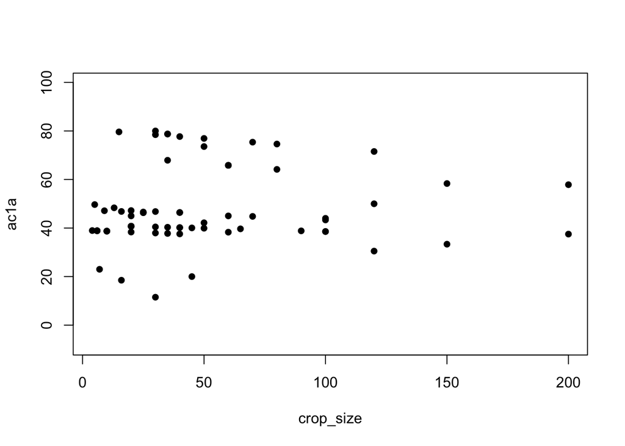

```r
xy<-cbind(x,y)
ac1a<-autocov_dist(crop_size, xy, nbs=1500, style="W", type="one")
plot(ac1a ~ crop_size, pch=16, asp=1)
```

```r
nb<-dnearneigh(xy, 0, 1500)
lw<-nb2listw(nb, style="W")
ac1b<-lag(lw, crop_size)
all.equal(ac1b, ac1a)
```

```
## [1] TRUE
```

And the `glm` model including the autocovariate looks like this:

```r
glm_cs<-glm(crop_size ~ temp + hum + lum + ac1b, data=data, family="poisson")
summary(glm_cs)
```

```
##
## Call:
## glm(formula = crop_size ~ temp + hum + lum + ac1b, family = "poisson",
##     data = data)
##
## Coefficients:
##               Estimate Std. Error z value Pr(>|z|)
## (Intercept)  1.086e+01  3.555e-01  30.548  < 2e-16 ***
## temp        -2.537e-01  1.302e-02 -19.479  < 2e-16 ***
## hum         -4.148e-02  2.290e-03 -18.112  < 2e-16 ***
## lum          3.519e-05  2.393e-06  14.706  < 2e-16 ***
## ac1b        -9.306e-03  1.270e-03  -7.325 2.39e-13 ***
## ---
## Signif. codes:  0 '***' 0.001 '**' 0.01 '*' 0.05 '.' 0.1 ' ' 1
##
## (Dispersion parameter for poisson family taken to be 1)
##
##     Null deviance: 2260.1  on 69  degrees of freedom
## Residual deviance: 1537.1  on 65  degrees of freedom
## AIC: 1923.5
##
## Number of Fisher Scoring iterations: 5
```

Now we will conduct the same model withour the spatial term for comparison purposes:

```r
glm_cs_s<-glm(crop_size ~ temp + hum + lum, data=data, family="poisson")
summary(glm_cs_s)
```

```
##
## Call:
## glm(formula = crop_size ~ temp + hum + lum, family = "poisson",
##     data = data)
##
## Coefficients:
##               Estimate Std. Error z value Pr(>|z|)
## (Intercept)  9.736e+00  3.169e-01   30.72   <2e-16 ***
## temp        -2.208e-01  1.206e-02  -18.32   <2e-16 ***
## hum         -3.877e-02  2.239e-03  -17.32   <2e-16 ***
## lum          2.960e-05  2.321e-06   12.76   <2e-16 ***
## ---
## Signif. codes:  0 '***' 0.001 '**' 0.01 '*' 0.05 '.' 0.1 ' ' 1
##
## (Dispersion parameter for poisson family taken to be 1)
##
##     Null deviance: 2260.1  on 69  degrees of freedom
## Residual deviance: 1592.2  on 66  degrees of freedom
## AIC: 1976.6
##
## Number of Fisher Scoring iterations: 5
```

Comparing model performance:

```r
AIC(glm_cs)
```

```
## [1] 1923.52
```

```r
AIC(glm_cs_s)
```

```
## [1] 1976.603
```

```r
comp1<-anova(glm_cs,glm_cs_s)
comp1
```

```
## Analysis of Deviance Table
##
## Model 1: crop_size ~ temp + hum + lum + ac1b
## Model 2: crop_size ~ temp + hum + lum
##   Resid. Df Resid. Dev Df Deviance
## 1        65     1537.1
## 2        66     1592.2 -1  -55.083
```

## The GAM approach

Taking advantage of GAM models, we can include the X,Y coordinates as a spline term in the model:

```r
gam_cs<-gam(crop_size ~ temp + hum + lum+s(x,y),data=data,family=poisson)
summary(gam_cs)
```

```
##
## Family: poisson
## Link function: log
##
## Formula:
## crop_size ~ temp + hum + lum + s(x, y)
##
## Parametric coefficients:
##               Estimate Std. Error z value Pr(>|z|)
## (Intercept)  8.511e+00  5.473e-01  15.552  < 2e-16 ***
## temp        -1.755e-01  3.285e-02  -5.343 9.13e-08 ***
## hum         -3.049e-02  8.638e-03  -3.530 0.000416 ***
## lum         -1.434e-05  7.881e-06  -1.820 0.068742 .
## ---
## Signif. codes:  0 '***' 0.001 '**' 0.01 '*' 0.05 '.' 0.1 ' ' 1
##
## Approximate significance of smooth terms:
##          edf Ref.df Chi.sq p-value
## s(x,y) 28.71  28.98  652.2  <2e-16 ***
## ---
## Signif. codes:  0 '***' 0.001 '**' 0.01 '*' 0.05 '.' 0.1 ' ' 1
##
## R-sq.(adj) =  0.356   Deviance explained =   65%
## UBRE = 11.239  Scale est. = 1         n = 70
```

```r
AIC(gam_cs)
```

```
## [1] 1233.153
```

This approach is much easier as we don’t need to create a coviate and including coordinates as a spline term largely reduced model’s AIC value.

## Examining residuals

One key goal of conducting spatially-explicit models is to improve residual distribution and properly deal with spatial autocorrelation,

How residuals look like?

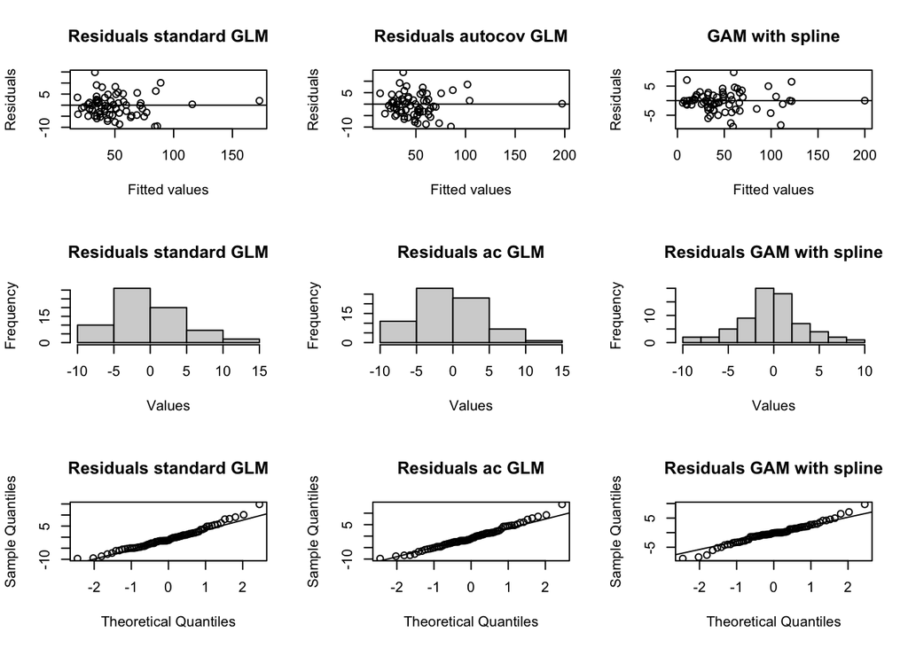

```r
###Regular GLM
res_cs_s<-residuals(glm_cs_s)
fres_cs_s<-fitted(glm_cs_s)
###autocov GLM
res_cs<-residuals(glm_cs)
fres_cs<-fitted(glm_cs)
###GAM
res_gcs<-residuals(gam_cs)
fres_gcs<-fitted(gam_cs)

###Plotting residuals
par(mfrow=c(3,3))
plot(res_cs_s ~ fres_cs_s, xlab="Fitted values", ylab="Residuals", main="Residuals standard GLM")
abline(h=0)
plot(res_cs ~ fres_cs, xlab="Fitted values", ylab="Residuals", main="Residuals autocov GLM")
abline(h=0)
plot(res_gcs ~ fres_gcs, xlab="Fitted values", ylab="Residuals", main="GAM with spline")
abline(h=0)
hist(res_cs_s, xlab="Values", ylab="Frequency", main="Residuals standard GLM")
hist(res_cs, xlab="Values", ylab="Frequency", main="Residuals ac GLM")
hist(res_gcs, xlab="Values", ylab="Frequency", main="Residuals GAM with spline")
qqnorm(res_cs_s, main="Residuals standard GLM")
qqline(res_cs_s)
qqnorm(res_cs, main="Residuals ac GLM")
qqline(res_cs)
qqnorm(res_gcs, main="Residuals GAM with spline")
qqline(res_gcs)
```

And what about residual spatial autocorrelation in the model?

```r
###Regular GLM
cr_res_css<-spline.correlog(x=x,y=y,z=res_cs_s, resamp=1000)
```

```
## 100  of  1000 200  of  1000 300  of  1000 400  of  1000 500  of  1000 600  of  1000 700  of  1000 800  of  1000 900  of  1000 1000  of  1000
```

```r
###autocov GLM
cr_res_cs<-spline.correlog(x=x,y=y,z=res_cs, resamp=1000)
```

```
## 100  of  1000 200  of  1000 300  of  1000 400  of  1000 500  of  1000 600  of  1000 700  of  1000 800  of  1000 900  of  1000 1000  of  1000
```

```r
###GAM
cr_res_gcs<-spline.correlog(x=x,y=y,z=res_gcs, resamp=1000)
```

```
## 100  of  1000 200  of  1000 300  of  1000 400  of  1000 500  of  1000 600  of  1000 700  of  1000 800  of  1000 900  of  1000 1000  of  1000
```

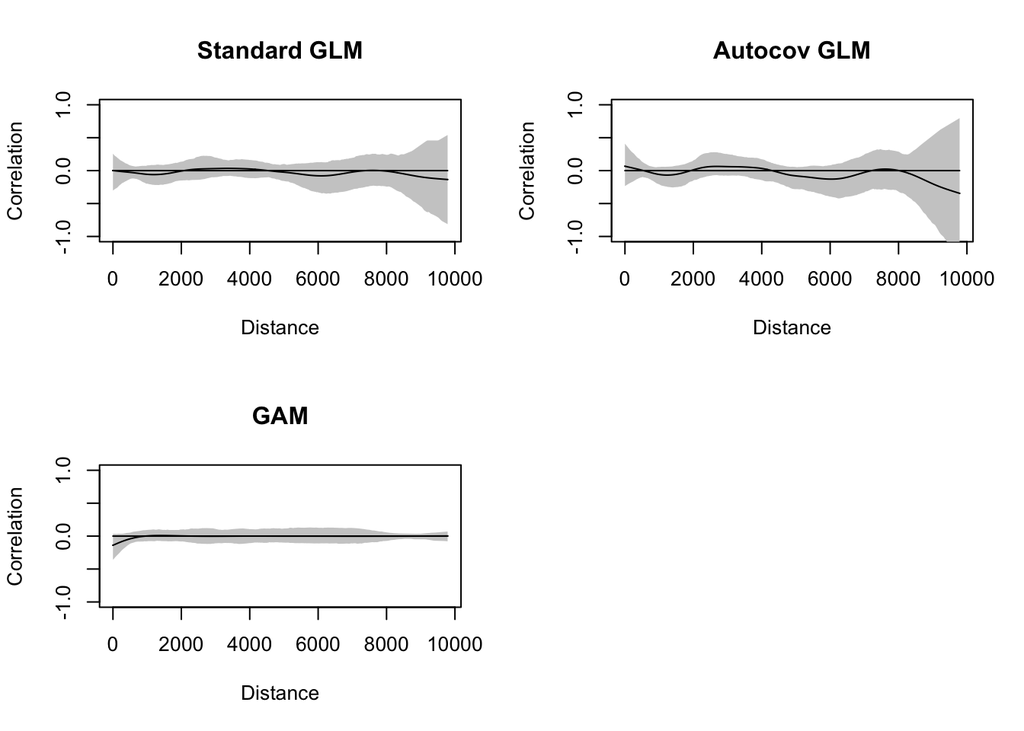

```r
###plots
par(mfrow=c(2,2))
plot(cr_res_css, main = "Standard GLM")
plot(cr_res_cs, main = "Autocov GLM")
plot(cr_res_gcs, main = "GAM")
par(mfrow=c(1,1))
```

As we can see, GAM models outsmart the other models!

Finally, let’s examine Mantel correlograms to see if such reduction in spatial autocorrelation is significant (black boxes indicate significant autocorrelation at a given distance class):

```r
mdist<-dist(xy)
mrcss<-dist(res_cs_s)
mrcs<-dist(res_cs)
mrgcs<-dist(res_gcs)
mpm_css<-mpmcorrelogram(mrcss,mdist,method="pearson",permutations=1000)
```

```
## evaluating distance class 1, 2, 3, 4, 5, 6, 7, 8, 9, 10, 11, 12,
```

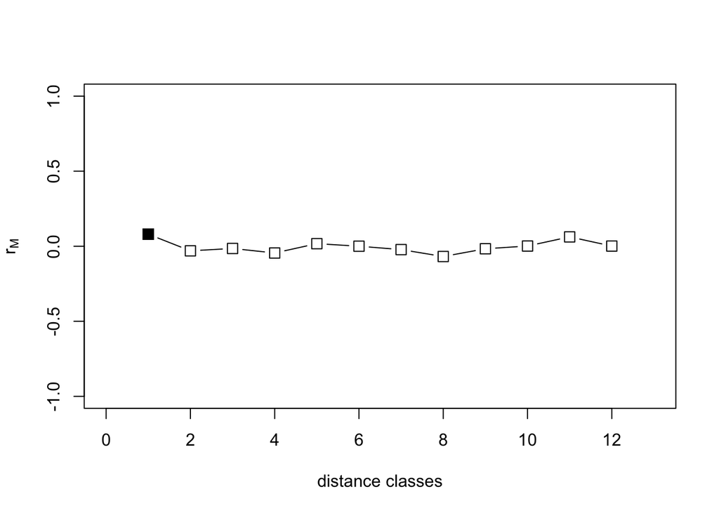

```
##    class        distance.range            rM          p p.Bonferroni
## 1      1         0  -  815.495  0.0803109560 0.02897103   0.02897103
## 2      2  815.495  -  1630.989 -0.0305568564 0.21678322   0.43356643
## 3      3 1630.989  -  2446.484 -0.0148290566 0.35064935   1.05194805
## 4      4 2446.484  -  3261.978 -0.0449395309 0.11788212   0.47152847
## 5      5 3261.978  -  4077.473  0.0171614668 0.33666334   1.68331668
## 6      6 4077.473  -  4892.967  0.0001745924 0.51948052   3.11688312
## 7      7 4892.967  -  5708.462 -0.0223615608 0.28971029   2.02797203
## 8      8 5708.462  -  6523.957 -0.0684178687 0.05194805   0.41558442
## 9      9 6523.957  -  7339.451 -0.0168132975 0.30369630   2.73326673
## 10    10 7339.451  -  8154.946  0.0014870995 0.56143856   5.61438561
## 11    11  8154.946  -  8970.44  0.0624031855 0.06393606   0.70329670
## 12    12  8970.44  -  9786.935  0.0011259013 0.53846154   6.46153846
```

```r
mpm_cs<-mpmcorrelogram(mrcs,mdist,method="pearson",permutations=1000)
```

```
## evaluating distance class 1, 2, 3, 4, 5, 6, 7, 8, 9, 10, 11, 12,
```

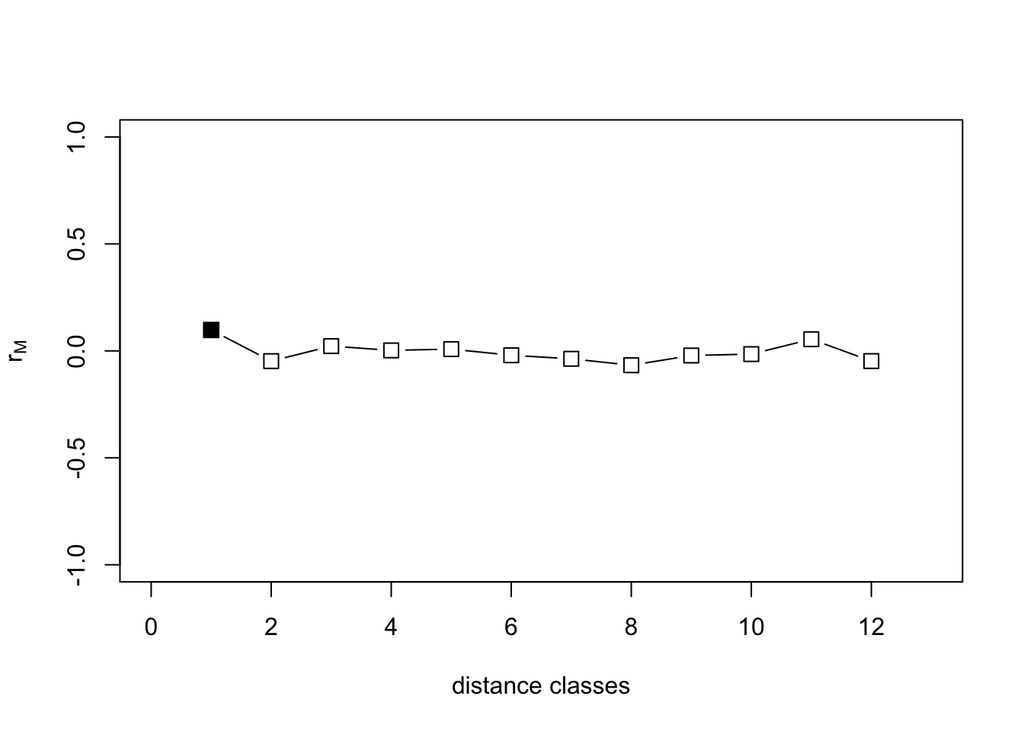

```
##    class        distance.range           rM           p p.Bonferroni
## 1      1         0  -  815.495  0.097745517 0.005994006  0.005994006
## 2      2  815.495  -  1630.989 -0.047885762 0.123876124  0.247752248
## 3      3 1630.989  -  2446.484  0.022385957 0.360639361  1.081918082
## 4      4 2446.484  -  3261.978  0.002280253 0.517482517  2.069930070
## 5      5 3261.978  -  4077.473  0.008282959 0.430569431  2.152847153
## 6      6 4077.473  -  4892.967 -0.020530247 0.231768232  1.390609391
## 7      7 4892.967  -  5708.462 -0.037016244 0.213786214  1.496503497
## 8      8 5708.462  -  6523.957 -0.067126907 0.053946054  0.431568432
## 9      9 6523.957  -  7339.451 -0.021626020 0.275724276  2.481518482
## 10    10 7339.451  -  8154.946 -0.015099262 0.318681319  3.186813187
## 11    11  8154.946  -  8970.44  0.054534828 0.097902098  1.076923077
## 12    12  8970.44  -  9786.935 -0.047592939 0.137862138  1.654345654
```

```r
mpm_gcs<-mpmcorrelogram(mrgcs,mdist,method="pearson",permutations=1000)
```

```
## evaluating distance class 1, 2, 3, 4, 5, 6, 7, 8, 9, 10, 11, 12,
```

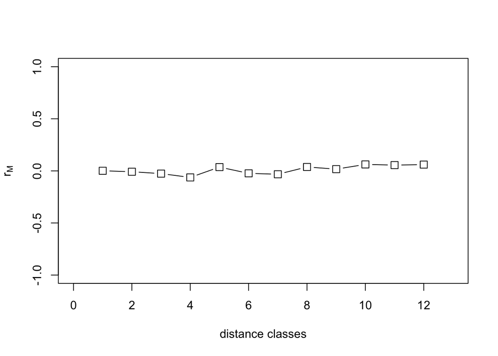

```
##    class        distance.range            rM          p p.Bonferroni
## 1      1         0  -  815.495  0.0009788197 0.47252747    0.4725275
## 2      2  815.495  -  1630.989 -0.0082363064 0.42557443    0.8511489
## 3      3 1630.989  -  2446.484 -0.0262129656 0.28871129    0.8661339
## 4      4 2446.484  -  3261.978 -0.0627072557 0.08591409    0.3436563
## 5      5 3261.978  -  4077.473  0.0363803620 0.15584416    0.7792208
## 6      6 4077.473  -  4892.967 -0.0235614077 0.25074925    1.5044955
## 7      7 4892.967  -  5708.462 -0.0325278905 0.24575425    1.7202797
## 8      8 5708.462  -  6523.957  0.0374416529 0.14285714    1.1428571
## 9      9 6523.957  -  7339.451  0.0168822466 0.39860140    3.5874126
## 10    10 7339.451  -  8154.946  0.0620151211 0.04295704    0.4295704
## 11    11  8154.946  -  8970.44  0.0555962626 0.12287712    1.3516484
## 12    12  8970.44  -  9786.935  0.0603013154 0.06193806    0.7432567
```

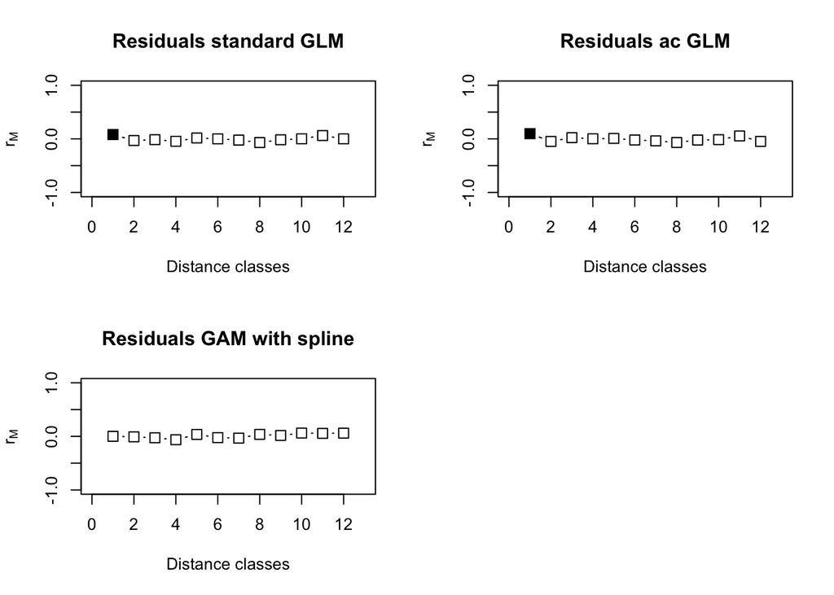

```r
###Plot
par(mfrow=c(2,2))
plot(mpm_css, xlab="Distance classes",main="Residuals standard GLM")
plot(mpm_cs, xlab="Distance classes",main="Residuals ac GLM")
plot(mpm_gcs, xlab="Distance classes",main="Residuals GAM with spline")
par(mfrow=c(1,1))
```

Again, the GAM model has the better performance as it has no significant autocorrelation along distance classes.

## Final thoughts

Spatially-explicit models allow us to include spatial structure information into our models. Instead of fighting it and trying to keep spatial structure controlled and out of the reach of our models, we can embrace it and examine it as part of our data, which results very informative. From many approaches available, here we compared the classic spatial autocovariate and the GAM approaches. The GAM approach outperformed the autocovariate approach, significantly improving model results.

Licensing Creative Commons License

Licensed under a Creative Commons Attribution-ShareAlike 4.0 International License.  
2022 - Francisco E. Fontúrbel